# Lab #1: Recreating a Figure in ggplot

For this lab, we will be using the `covid_testing` data from the `medicaldata` R package. Please explore this package at https://github.com/higgi13425/medicaldata.

Your task will be to recreate the plot shown below using this data:

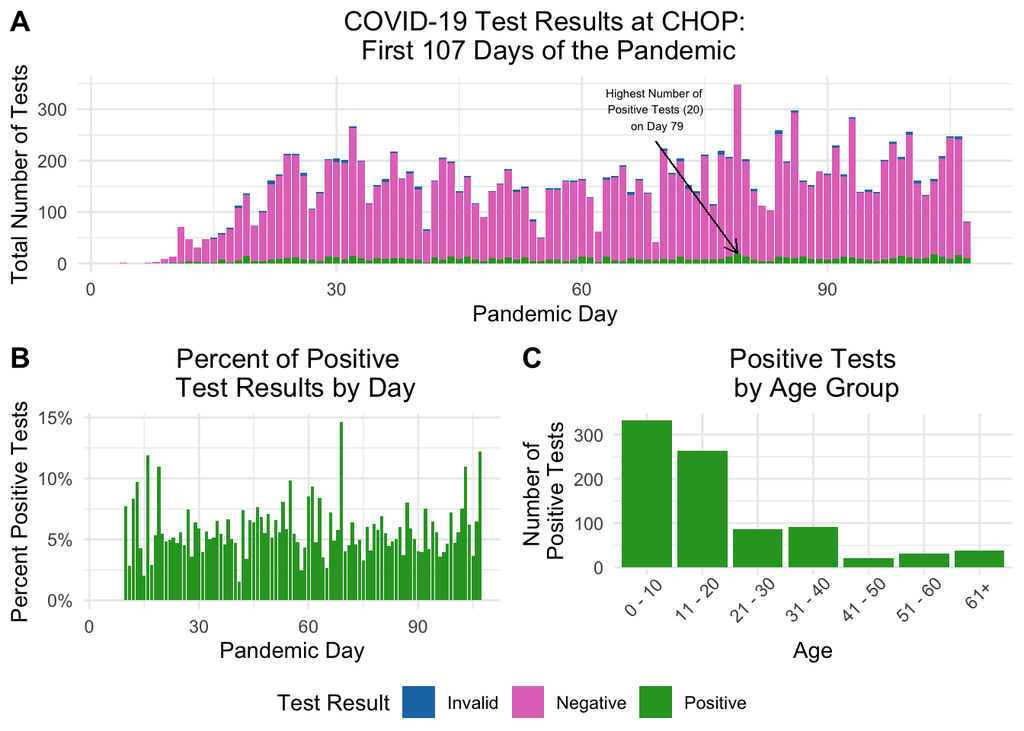

The rubric for grading is shown below. The assignment is worth **100 pts**.

- **Code Style (10 pts)** Is code organized according to the style guide and commented?
- **Submission (15 pts)** Was the lab submitted as an html document on Canvas? Does the html document look aesthetically pleasing? Did the lab contain a link for a GitHub repository? Did the repository contain the code for the assignment?
- **Participation (20 pts)** Did you work with your group during the lab?
- **Plot A (15 pts)** Did you successfully re-create Plot A?
- **Plot B (15 pts)** Did you successfully re-create Plot B?
- **Plot C (15 pts)** Did you successfully re-create Plot C?
- **Putting Plots Together (10 pts)** Were you able to put the plots together?

# Instructions

## Load libraries and data wrangling

- Load required libraries
- Assign the data from `medicaldata::covid_testing` to a new `covid` dataframe
- Filter the data for only COVID tests
- Change the test results to all start with capital letters (hint: check out the function `stringr::str_to_title`)
- Create a new dataframe `covid_summary` that calculates the percent of positive tests per day (hint: use `summarise()`)
- Create a new dataframe `covid_ages` that filters the data for only positive test results and creates a variable for age categories (0 - 10, 11 - 20, 21 - 30, 31 - 40, 41 - 50, 51 - 60, 61+)

## Plot A

- Make a stacked bar plot of the test results by day
- Change the colors using the following hex code colors: #1f77b4, #e377c2 and #2ca02c
- Change the labels on the x-axis, y-axis, title, and legend
- Use `theme_minimal()` to remove the gray background
- Use `theme()` to center the title
- Use `geom_segment()` and `annotate()` to draw the arrow and write text on the plot

## Plot B

- Use the `covid_summary` dataframe
- Make a bar plot and change the colors of your bar plot
- Using `scale_y_continuous()` change the y-axis labels to percents
- Change the labels on the x-axis, y-axis, and title
- Use `theme_minimal()` to remove the gray background
- Use `theme()` to center the title and remove the legend

## Plot C

- Use the `covid_ages` dataframe
- Make a bar plot and change the colors of your bar plot
- Use `theme_minimal()` to remove the gray background
- Use `theme()` to center the title, remove the legend, and rotate the x-axis labels

## Putting the plots together

- Use `ggpubr::ggarrange` to arrange the plots
- Label the plots “A”, “B”, and “C”
- Create a common legend and put this at the bottom of the plot